# PUBHBIO 6211: Practice Exercises Block 1

# Exercise 1

I have observations on systolic blood pressure (SBP) and age for a sample of 30 adults. A linear regression using age to predict SBP was conducted; Stata output is below.

```stata
. regress sbp age

      Source |       SS       df       MS              Number of obs =      30
-------------+------------------------------           F(  1,    28) =   21.33
       Model |  6394.02269     1  6394.02269           Prob > F      =  0.0001
    Residual |  8393.44398    28  299.765856           R-squared     =  0.4324
-------------+------------------------------           Adj R-squared =  0.4121
       Total |  14787.4667    29  509.912644           Root MSE      =  17.314

------------------------------------------------------------------------------
         sbp |      Coef.   Std. Err.      t    P>|t|     [95% Conf. Interval]
-------------+----------------------------------------------------------------
         age |   .9708704   .2102157     4.62   0.000     .5402629    1.401478
       _cons |   98.71472   10.00047     9.87   0.000     78.22969    119.1997
------------------------------------------------------------------------------
```

1. Interpret the intercept estimate. Is it meaningful?
2. Interpret the slope estimate.
3. What is the estimated mean SBP for a person who is 30 years old?
4. What is the estimated difference in mean SBP for a person who is 45 years old compared to a person who is 30 years old? (And clearly state which mean is higher.)
5. Is there evidence of a significant association between age and SBP? Cite specific evidence from the output (i.e., a p-value).
6. What is the coefficient of determination for this model? Write a one sentence interpretation of this quantity.

# Exercise 2

Information on 74 automobiles was collected (in 1978) to study the relationship between gas mileage (mpg) and various features of the cars. In particular, we are interested in the relationship between mileage and weight of the car, measured in pounds. A linear regression produced the (incomplete) Stata output below.

```stata
. regress mpg pounds

      Source |       SS           df       MS      Number of obs   =        74
-------------+----------------------------------   F(1, 72)        =    134.62
       Model |   1591.9902         1   1591.9902   Prob > F        =
    Residual |  851.469256        72  11.8259619   R-squared       =
-------------+----------------------------------   Adj R-squared   =    0.6467
       Total |  2443.45946        73  33.4720474   Root MSE        =    3.4389

------------------------------------------------------------------------------
         mpg |      Coef.   Std. Err.      t    P>|t|     [95% Conf. Interval]
-------------+----------------------------------------------------------------
      pounds |  -.0060087   .0005179
       _cons |   39.44028   1.614003    24.44   0.000     36.22283    42.65774
------------------------------------------------------------------------------
```

1. Write the estimated regression equation.
2. Interpret the number 39.44 in the above output.
3. Interpret the number -0.0060087 in the above output.
4. What is the estimated change in MPG for a 1 U.S. ton increase in car weight? (Note: 1 U.S. ton = 2000 pounds)
5. Test whether there is a significant effect of weight on mileage.
6. Calculate a 95% confidence interval for $\beta_1$. Do you expect 0 to be in the interval?
7. The $R^2$ value is missing from the output. Calculate it.
8. Calculate the correlation between MPG and pounds.
1. If I convert the weight of the car from pounds to kilograms and rerun the regression model (i.e., use weight in kilograms to predict MPG), will the slope estimate change? Will the $R^2$ change?
10. The p-value for the overall F-test is missing from the output. What is it?
11. Three plots generated after running the regression model are shown below (labeled A-C). For each plot, state the name of the plot (or what is being plotted), which assumption(s) of the model can be checked with the plot, and whether or not you see any problems with the assumptions.

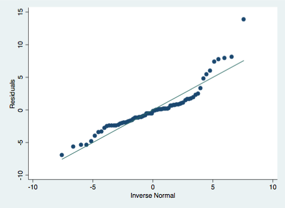

Plot A

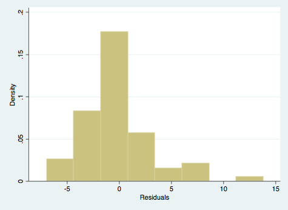

Plot B

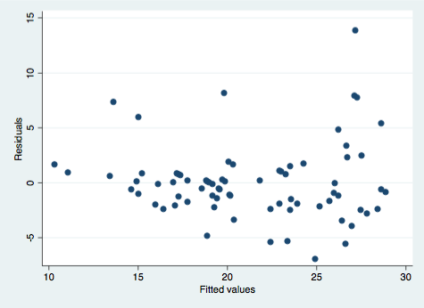

Plot C

# Exercise 3

An economist is interested in the relationship between money flowing to stock mutual funds and money flowing into bond mutual funds. She collects data on the net new money flow into stocks and bonds for each year from 1985 to 2000 (in billions of dollars) and adjusts for inflation. She then uses Stata to run the regression model: $E(BONDS) = \beta_0 + \beta_1 \times STOCKS$

```stata
. regress bonds stocks

      Source |       SS           df       MS      Number of obs   =        16
-------------+----------------------------------   F(1, 14)        =      1.60
       Model |  5749.11511         1  5749.11511   Prob > F        =    ______
    Residual |  50200.7429        14  3585.76735   R-squared       =    ______
-------------+----------------------------------   Adj R-squared   =    0.0387
       Total |   55949.858        15  3729.99053   Root MSE        =    59.881

------------------------------------------------------------------------------
       bonds |      Coef.   Std. Err.      t    P>|t|     [95% Conf. Interval]
-------------+----------------------------------------------------------------
      stocks |  -.1962223   .1549669    -1.27   _____    -.5285933    .1361486
       _cons |   53.40959    22.9925     2.32   0.036      4.09557    102.7236
------------------------------------------------------------------------------
```

1. The p-value for the test of $H_0: \beta_1=0$ is missing from the output. Based only on the confidence interval, what do you know about the missing p-value? (Hint: would you reject or fail to reject $H_0$?)
2. The $R^2$ value is also missing. Calculate it.